# TCC CASE Cyclistic

Eduardo Rahel

2025-05-12

# Análise de Comportamento de Uso dos Ciclistas da Cyclistic

## Introdução

O presente estudo visa identificar padrões no comportamento de uso das bicicletas compartilhadas da Cyclistic, com foco na comparação entre os perfis de **usuários membros** (assinantes) e **usuários casuais**. A análise foi conduzida com base em dados reais coletados pela empresa, considerando as variáveis de tempo de uso, dia da semana e tipo de bicicleta utilizada.

O objetivo principal é subsidiar a equipe de marketing na formulação de estratégias que convertam usuários casuais em membros recorrentes, ampliando assim a base de receita da empresa.

## Etapas de Preparação e Análise dos dados

### Etapa 1 – Preparar: Importação e Organização dos Dados no R

#### Carregando os pacotes

```r
library("tidyverse")
library("janitor")
```

#### Definindo o caminho da pasta onde estão os arquivos

```r
dados_bike <- read.csv (
  file = "c:/Temp/dados_cyclistic.csv"
  )
```

#### Limpando os nomes das colunas (formato snake_case)

```r
dados_cyclistic <- clean_names(dados_bike)
```

#### Visualizando a Estrutura

```r
glimpse(dados_cyclistic)
```

```
## Rows: 5,735,884
## Columns: 13
## $ ride_id            <chr> "7D9F0CE9EC2A1297", "02EC47687411416F", "101370FB2D…
## $ rideable_type      <chr> "classic_bike", "classic_bike", "classic_bike", "el…
## $ started_at         <chr> "2024-05-25 15:52:42", "2024-05-14 15:11:51", "2024…
## $ ended_at           <chr> "2024-05-25 16:11:50", "2024-05-14 15:22:00", "2024…
## $ start_station_name <chr> "Streeter Dr & Grand Ave", "Sheridan Rd & Greenleaf…
## $ start_station_id   <chr> "13022", "KA1504000159", "13022", "13022", "KA15040…
## $ end_station_name   <chr> "Clark St & Elm St", "Sheridan Rd & Loyola Ave", "W…
## $ end_station_id     <chr> "TA1307000039", "RP-009", "TA1309000010", "TA130700…
## $ start_lat          <dbl> 41.89228, 42.01059, 41.89228, 41.89227, 41.90349, 4…
## $ start_lng          <dbl> -87.61204, -87.66241, -87.61204, -87.61195, -87.643…
## $ end_lat            <dbl> 41.90297, 42.00104, 41.87077, 41.93625, 41.90297, 4…
## $ end_lng            <dbl> -87.63128, -87.66120, -87.62573, -87.65266, -87.631…
## $ member_casual      <chr> "casual", "casual", "member", "member", "casual", "…
```

```r
head(dados_cyclistic)
```

```
##            ride_id rideable_type          started_at            ended_at
## 1 7D9F0CE9EC2A1297  classic_bike 2024-05-25 15:52:42 2024-05-25 16:11:50
## 2 02EC47687411416F  classic_bike 2024-05-14 15:11:51 2024-05-14 15:22:00
## 3 101370FB2D3402BE  classic_bike 2024-05-30 17:46:04 2024-05-30 18:09:16
## 4 E97E396331ED6913 electric_bike 2024-05-17 20:21:54 2024-05-17 20:40:32
## 5 674EDE311C543165  classic_bike 2024-05-22 18:52:20 2024-05-22 18:59:04
## 6 2E3EA4C19F0341A6 electric_bike 2024-05-25 19:32:12 2024-05-25 19:36:17
##            start_station_name start_station_id               end_station_name
## 1     Streeter Dr & Grand Ave            13022              Clark St & Elm St
## 2 Sheridan Rd & Greenleaf Ave     KA1504000159       Sheridan Rd & Loyola Ave
## 3     Streeter Dr & Grand Ave            13022            Wabash Ave & 9th St
## 4     Streeter Dr & Grand Ave            13022 Sheffield Ave & Wellington Ave
## 5   Larrabee St & Division St     KA1504000079              Clark St & Elm St
## 6 Sheridan Rd & Greenleaf Ave     KA1504000159       Sheridan Rd & Loyola Ave
##   end_station_id start_lat start_lng  end_lat   end_lng member_casual
## 1   TA1307000039  41.89228 -87.61204 41.90297 -87.63128        casual
## 2         RP-009  42.01059 -87.66241 42.00104 -87.66120        casual
## 3   TA1309000010  41.89228 -87.61204 41.87077 -87.62573        member
## 4   TA1307000052  41.89227 -87.61195 41.93625 -87.65266        member
## 5   TA1307000039  41.90349 -87.64335 41.90297 -87.63128        casual
## 6         RP-009  42.01057 -87.66246 42.00104 -87.66120        casual
```

# Etapa 2 – Processar: Limpeza e Transformações dos Dados

#### Transformando os campos de texto started_at e ended_at em data-hora para realizar cálculos

```r
dados_cyclistic <- dados_cyclistic %>%
  mutate(
    started_at = ymd_hms(started_at),
    ended_at   = ymd_hms(ended_at)
  )
```

#### Criando a coluna ride_length em minutos

```r
dados_cyclistic <- dados_cyclistic %>%
  mutate(ride_length = as.numeric(difftime(ended_at, started_at, units = "mins")))
```

#### Dia da semana como nome (Segunda, Terça…)

```r
dados_cyclistic <- dados_cyclistic %>%
  mutate(day_of_week = wday(started_at, label = TRUE, abbr = FALSE))
```

```r
dados_cyclistic <- dados_cyclistic %>%
  mutate(day_of_week_num = wday(started_at, week_start = 1))
```

#### Verificando o resultado

```r
glimpse(dados_cyclistic)
```

```
## Rows: 5,735,884
## Columns: 16
## $ ride_id            <chr> "7D9F0CE9EC2A1297", "02EC47687411416F", "101370FB2D…
## $ rideable_type      <chr> "classic_bike", "classic_bike", "classic_bike", "el…
## $ started_at         <dttm> 2024-05-25 15:52:42, 2024-05-14 15:11:51, 2024-05-…
## $ ended_at           <dttm> 2024-05-25 16:11:50, 2024-05-14 15:22:00, 2024-05-…
## $ start_station_name <chr> "Streeter Dr & Grand Ave", "Sheridan Rd & Greenleaf…
## $ start_station_id   <chr> "13022", "KA1504000159", "13022", "13022", "KA15040…
## $ end_station_name   <chr> "Clark St & Elm St", "Sheridan Rd & Loyola Ave", "W…
## $ end_station_id     <chr> "TA1307000039", "RP-009", "TA1309000010", "TA130700…
## $ start_lat          <dbl> 41.89228, 42.01059, 41.89228, 41.89227, 41.90349, 4…
## $ start_lng          <dbl> -87.61204, -87.66241, -87.61204, -87.61195, -87.643…
## $ end_lat            <dbl> 41.90297, 42.00104, 41.87077, 41.93625, 41.90297, 4…
## $ end_lng            <dbl> -87.63128, -87.66120, -87.62573, -87.65266, -87.631…
## $ member_casual      <chr> "casual", "casual", "member", "member", "casual", "…
## $ ride_length        <dbl> 19.1333333, 10.1500000, 23.2000000, 18.6333333, 6.7…
## $ day_of_week        <ord> sábado, terça-feira, quinta-feira, sexta-feira, qua…
## $ day_of_week_num    <dbl> 6, 2, 4, 5, 3, 6, 5, 7, 7, 1, 2, 1, 1, 4, 4, 2, 5, …
```

```r
head(dados_cyclistic)
```

```
##            ride_id rideable_type          started_at            ended_at
## 1 7D9F0CE9EC2A1297  classic_bike 2024-05-25 15:52:42 2024-05-25 16:11:50
## 2 02EC47687411416F  classic_bike 2024-05-14 15:11:51 2024-05-14 15:22:00
## 3 101370FB2D3402BE  classic_bike 2024-05-30 17:46:04 2024-05-30 18:09:16
## 4 E97E396331ED6913 electric_bike 2024-05-17 20:21:54 2024-05-17 20:40:32
## 5 674EDE311C543165  classic_bike 2024-05-22 18:52:20 2024-05-22 18:59:04
## 6 2E3EA4C19F0341A6 electric_bike 2024-05-25 19:32:12 2024-05-25 19:36:17
##            start_station_name start_station_id               end_station_name
## 1     Streeter Dr & Grand Ave            13022              Clark St & Elm St
## 2 Sheridan Rd & Greenleaf Ave     KA1504000159       Sheridan Rd & Loyola Ave
## 3     Streeter Dr & Grand Ave            13022            Wabash Ave & 9th St
## 4     Streeter Dr & Grand Ave            13022 Sheffield Ave & Wellington Ave
## 5   Larrabee St & Division St     KA1504000079              Clark St & Elm St
## 6 Sheridan Rd & Greenleaf Ave     KA1504000159       Sheridan Rd & Loyola Ave
##   end_station_id start_lat start_lng  end_lat   end_lng member_casual
## 1   TA1307000039  41.89228 -87.61204 41.90297 -87.63128        casual
## 2         RP-009  42.01059 -87.66241 42.00104 -87.66120        casual
## 3   TA1309000010  41.89228 -87.61204 41.87077 -87.62573        member
## 4   TA1307000052  41.89227 -87.61195 41.93625 -87.65266        member
## 5   TA1307000039  41.90349 -87.64335 41.90297 -87.63128        casual
## 6         RP-009  42.01057 -87.66246 42.00104 -87.66120        casual
##   ride_length  day_of_week day_of_week_num
## 1   19.133333       sábado               6
## 2   10.150000  terça-feira               2
## 3   23.200000 quinta-feira               4
## 4   18.633333  sexta-feira               5
## 5    6.733333 quarta-feira               3
## 6    4.083333       sábado               6
```

# Etapa 3 – Limpeza Final dos Dados

```r
dados_cyclistic_clean <- dados_cyclistic %>%
  filter(!is.na(ride_length) & ride_length > 0 & ride_length <= 1440)
```

# Etapa 4 – Analisar: Estatísticas Descritivas no R

#### Média, Máximo, Mínimo da Duração por Tipo de Usuário

```r
dados_cyclistic %>%
  group_by(member_casual) %>%
  summarise(
    media_minutos = mean(ride_length),
    mediana = median(ride_length),
    maximo = max(ride_length),
    minimo = min(ride_length),
    total_viagens = n()
  )
```

```
## # A tibble: 3 × 6
##   member_casual media_minutos mediana maximo  minimo total_viagens
##   <chr>                 <dbl>   <dbl>  <dbl>   <dbl>         <int>
## 1 ""                     NA     NA       NA     NA          371341
## 2 "casual"               24.7   12.0   1560.   -66.8       2003451
## 3 "member"               12.5    8.67  1500. -2748.        3361092
```

#### Distribuição por Dia da Semana (ordenado)

```r
library("forcats")
```

```r
dados_cyclistic_clean %>%
  mutate(day_of_week = fct_relevel(day_of_week,
                                   "Domingo", "Segunda-feira", "Terça-feira", "Quarta-feira", "Quinta-feira", "Sexta-feira", "Sábado")) %>%
  group_by(member_casual, day_of_week) %>%
  summarise(total_viagens = n()) %>%
  arrange(member_casual, day_of_week)
```

```
## # A tibble: 14 × 3
## # Groups:   member_casual [2]
##    member_casual day_of_week   total_viagens
##    <chr>         <ord>                 <int>
##  1 casual        domingo              335708
##  2 casual        segunda-feira        229894
##  3 casual        terça-feira          207702
##  4 casual        quarta-feira         252509
##  5 casual        quinta-feira         249628
##  6 casual        sexta-feira          308930
##  7 casual        sábado               413565
##  8 member        domingo              376803
##  9 member        segunda-feira        477484
## 10 member        terça-feira          499127
## 11 member        quarta-feira         551123
## 12 member        quinta-feira         518459
## 13 member        sexta-feira          496278
## 14 member        sábado               440682
```

## Análise dos Gráficos e Resultados

### 1. Volume de viagens por dia da semana

O gráfico revela um aumento no volume de viagens realizadas por usuários casuais durante os fins de semana, especialmente aos sábados e domingos, sugerindo um uso voltado para lazer e turismo. Em contrapartida, os membros assinantes apresentam maior volume de uso durante os dias úteis, indicando um padrão mais funcional, associado à rotina de deslocamentos diários, como o trajeto entre casa e trabalho. Nos dias úteis, o número de viagens realizadas por usuários casuais é significativamente menor.

```r
library(ggplot2)
```

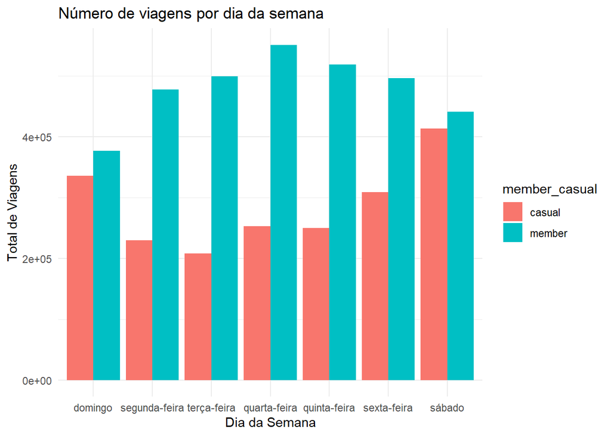

```r
dados_cyclistic_clean %>%
  mutate(day_of_week = fct_relevel(day_of_week,
                                   "Domingo", "Segunda-feira", "Terça-feira", "Quarta-feira", "Quinta-feira", "Sexta-feira", "Sábado")) %>%
  group_by(member_casual, day_of_week) %>%
  summarise(total = n()) %>%
  ggplot(aes(x = day_of_week, y = total, fill = member_casual)) +
  geom_col(position = "dodge") +
  labs(title = "Número de viagens por dia da semana", x = "Dia da Semana", y = "Total de Viagens") +
  theme_minimal()
```

### 2. Tempo médio por dia da semana

É possível observar que os usuários casuais tendem a utilizar as bicicletas por mais tempo aos finais de semana, com destaque para sábados e domingos, o que corrobora o comportamento voltado ao lazer. Já os membros assinantes mantêm um tempo médio de uso mais estável ao longo da semana, com pequenas variações nos dias úteis. Esses dados reforçam a ideia de que os casuais priorizam passeios mais longos e recreativos, enquanto os membros utilizam o serviço de forma mais objetiva e funcional.

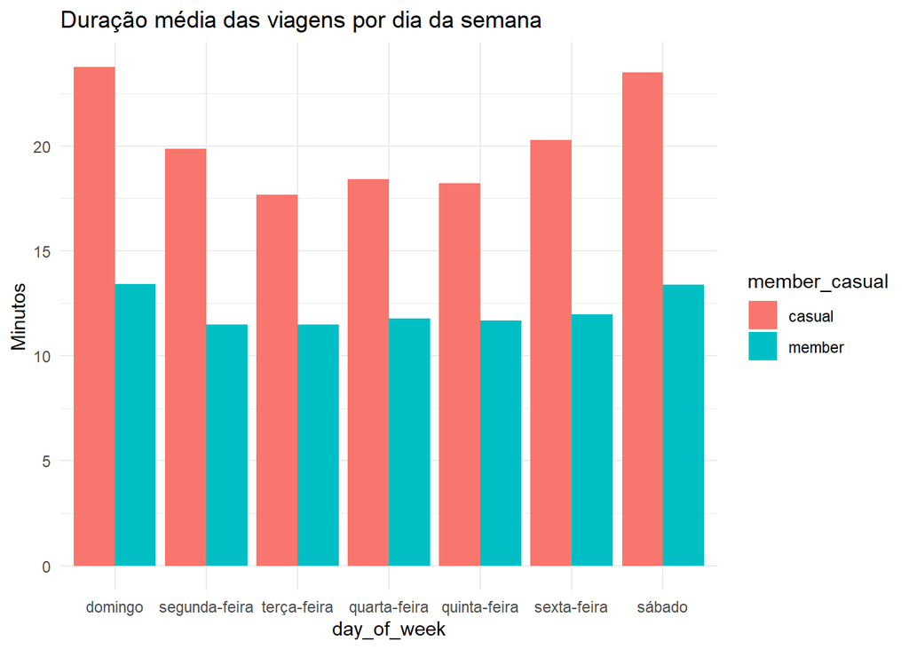

```r
dados_cyclistic_clean %>%
  group_by(member_casual, day_of_week) %>%
  summarise(media_duracao = mean(ride_length)) %>%
  ggplot(aes(x = day_of_week, y = media_duracao, fill = member_casual)) +
  geom_col(position = "dodge") +
  labs(title = "Duração média das viagens por dia da semana", y = "Minutos") +
  theme_minimal()
```

#### Tipo de bicicleta mais usado por grupo (membros x casuais)

#### Agrupamento + Contagem

```r
bike_tipo <- dados_cyclistic_clean %>%
  group_by(member_casual, rideable_type) %>%
  summarise(total_viagens = n()) %>%
  arrange(desc(total_viagens))
```

A análise mostra uma predominância no uso de bicicletas elétricas por ambos os grupos, casuais e membros. No entanto, os usuários casuais também fazem uso considerável das bicicletas clássicas, embora em proporção um pouco menor. Isso pode indicar que os casuais valorizam características como conforto, facilidade e agilidade, buscando uma experiência mais agradável e menos exigente fisicamente — fatores presentes nas bicicletas elétricas.

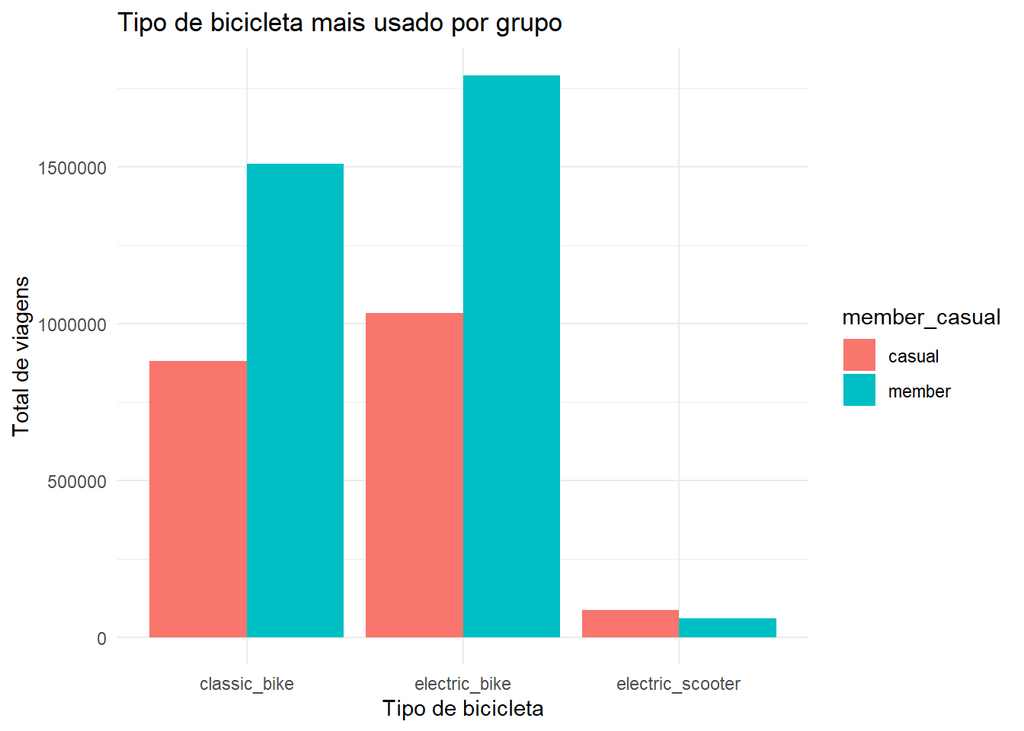

```r
ggplot(bike_tipo, aes(x = rideable_type, y = total_viagens, fill = member_casual)) +
  geom_col(position = "dodge") +
  labs(title = "Tipo de bicicleta mais usado por grupo",
       x = "Tipo de bicicleta",
       y = "Total de viagens") +
  theme_minimal()
```

### 4. Estações de partida mais utilizadas

O gráfico evidencia que uma grande quantidade de viagens tem como ponto de partida uma estação identificada como desconhecida ou não registrada. Isso pode comprometer a precisão das análises relacionadas à localização. É recomendável investigar as causas dessa lacuna — como falhas no sistema de coleta de dados ou uso de pontos alternativos — para que se possa melhorar a qualidade da base e, consequentemente, a assertividade das decisões futuras.

```r
top_estacoes <- dados_cyclistic_clean %>%
  mutate(start_station_name = ifelse(start_station_name == "" | is.na(start_station_name),
                                     "Estação Desconhecida", start_station_name)) %>%
  group_by(member_casual, start_station_name) %>%
  summarise(total_viagens = n()) %>%
  arrange(member_casual, desc(total_viagens)) %>%
  group_by(member_casual) %>%
  slice_max(total_viagens, n = 10)
```

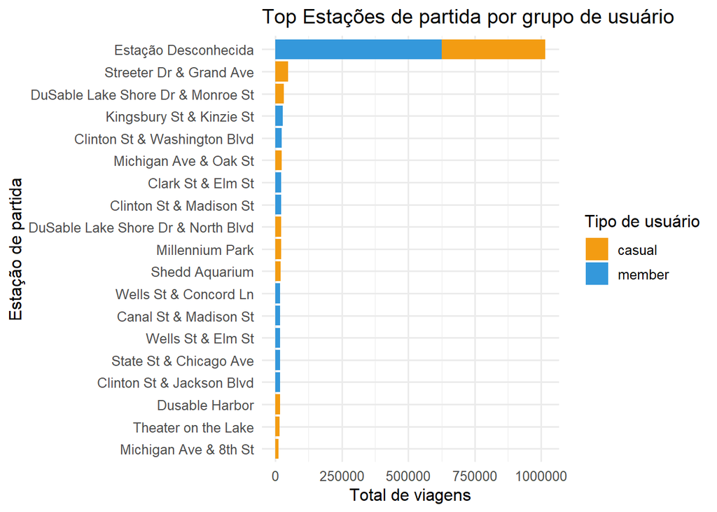

```r
ggplot(top_estacoes, aes(x = reorder(start_station_name, total_viagens), y = total_viagens, fill = member_casual)) +
  geom_col() +
  coord_flip() +
  scale_fill_manual(values = c("casual" = "#F39C12", "member" = "#3498DB")) +
  labs(title = "Top Estações de partida por grupo de usuário",
       x = "Estação de partida",
       y = "Total de viagens",
       fill = "Tipo de usuário") +
  theme_minimal(base_size = 12)
```

### 5. Volume de viagens por hora do dia

Os dados indicam um pico no uso das bicicletas entre 15h e 19h, especialmente entre os membros assinantes, o que sugere uma forte correlação com o horário de saída do trabalho. Curiosamente, usuários casuais também apresentam aumento no volume de viagens nesse mesmo período, possivelmente aproveitando o final do expediente para passeios urbanos. Essa coincidência de horários pode indicar concorrência por disponibilidade nos momentos de maior demanda.

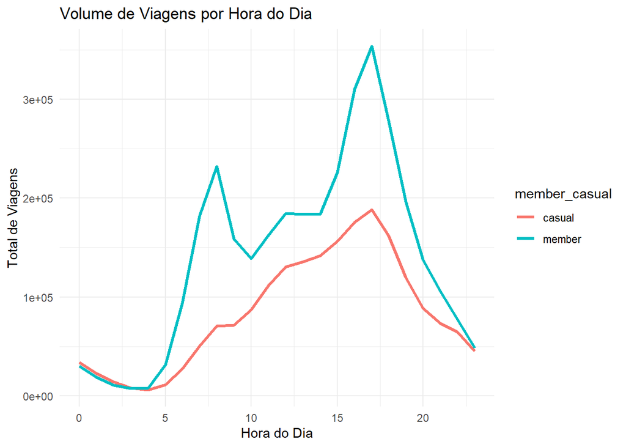

```r
dados_cyclistic_clean %>%
  mutate(hora = hour(started_at)) %>%
  group_by(member_casual, hora) %>%
  summarise(total_viagens = n()) %>%
  ggplot(aes(x = hora, y = total_viagens, color = member_casual)) +
  geom_line(size = 1.2) +
  labs(title = "Volume de Viagens por Hora do Dia",
       x = "Hora do Dia", y = "Total de Viagens") +
  theme_minimal()
```

A análise mostra que aproximadamente 50% das viagens são realizadas com bicicletas elétricas, o que destaca sua popularidade entre os usuários. Isso pode ser atribuído à praticidade, agilidade e menor esforço físico exigido, além de ser uma alternativa ainda considerada “moderna” por muitos. Por outro lado, as bicicletas clássicas continuam mantendo uma parcela significativa de uso, provavelmente devido ao custo-benefício percebido, sendo preferidas por usuários que buscam economia.

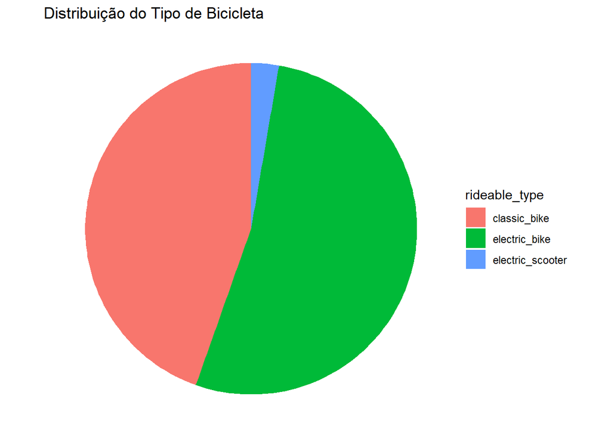

```r
bike_tipo %>%
  group_by(rideable_type) %>%
  summarise(total = sum(total_viagens)) %>%
  ggplot(aes(x = "", y = total, fill = rideable_type)) +
  geom_col(width = 1) +
  coord_polar(theta = "y") +
  labs(title = "Distribuição do Tipo de Bicicleta") +
  theme_void()
```

## Aplicação dos Insights pela Empresa

Com esses dados, a equipe da Cyclistic pode:

1. **Criar campanhas direcionadas** para usuários casuais durante o final de semana, oferecendo descontos na assinatura mensal.
2. **Promover benefícios exclusivos** para casuais que experimentarem a assinatura — como minutos extras gratuitos ou acesso prioritário a bikes elétricas.
3. **Ajustar a frota de bicicletas**, priorizando bicicletas elétricas em áreas turísticas aos fins de semana, onde há maior fluxo de casuais.
4. **Investir em comunicações segmentadas**: mostrar aos casuais os benefícios práticos de ser membro, como economia e conveniência nos deslocamentos diários.

## Próximos Passos e Expansões Futuras

**Próximos passos recomendados:**

- **Segmentação geográfica**: cruzar os dados com localização para identificar onde estão os maiores grupos de casuais.
- **Análise de sazonalidade**: verificar variações mensais ou sazonais no uso para campanhas em períodos estratégicos.
- **Testes A/B de campanhas**: testar diferentes abordagens promocionais com casuais para mensurar conversões em membros.
- **Análise de churn dos membros**: identificar por que usuários deixam de ser membros e corrigir gargalos no serviço.

## Possibilidades com Dados Adicionais

Caso estejam disponíveis, os seguintes dados poderiam enriquecer a análise:

- **Dados demográficos** dos usuários (idade, gênero, local de residência).
- **Feedbacks qualitativos** dos casuais (pesquisas de satisfação, avaliações).
- **Eventos locais** ou sazonalidades (feriados, festivais) correlacionados aos picos de uso.
- **Clima/tempo**: entender o impacto das condições climáticas no comportamento de uso.